# Demo RStudio and EDA

## Exercise 8 from ISLR Chapter 2

The following illustrate commands for exploring this exercise using R and various packages for the `Collage` data.

### Libraries

Try to load the `ISLR` library

```r
library(ISLR) #load the library
```

If it is not available you will need to install the library from CRAN. Click on *Packages* then *Install*. Enter the package name then click on the Install button.

You can also install from the console/command line using `install.packages("ISLR")`.

Ready?

### Getting the College data

Next we will need to load the dataset. This is part of the library so we will not need to read it in using `read.csv` but rather we will use the `data` function to load it from the library.

```r
data(College)
```

This loads the dataframe `College`. Note you can always see the content of any `R` object by simply typing its name.

For information about the variables, read the text or enter

```r
help(College)
```

The info will appear in the `help` tab.

To see explore the data, you can use the command `View(College)`.

This will open a new tab, where you may scroll left and right to look at the rows and columns. In the `View` you should see that the first column is the College/University name. These can be extracted using `rownames(College)`. Let’s print out the first 5

```r
rownames(College)[1:5]
```

```
[1] "Abilene Christian University" "Adelphi University"           "Adrian College"
[4] "Agnes Scott College"          "Alaska Pacific University"
```

### Summary

```r
summary(College)
```

```
 Private        Apps           Accept          Enroll       Top10perc       Top25perc      F.Undergrad
 No :212   Min.   :   81   Min.   :   72   Min.   :  35   Min.   : 1.00   Min.   :  9.0   Min.   :  139
 Yes:565   1st Qu.:  776   1st Qu.:  604   1st Qu.: 242   1st Qu.:15.00   1st Qu.: 41.0   1st Qu.:  992
           Median : 1558   Median : 1110   Median : 434   Median :23.00   Median : 54.0   Median : 1707
           Mean   : 3002   Mean   : 2019   Mean   : 780   Mean   :27.56   Mean   : 55.8   Mean   : 3700
           3rd Qu.: 3624   3rd Qu.: 2424   3rd Qu.: 902   3rd Qu.:35.00   3rd Qu.: 69.0   3rd Qu.: 4005
           Max.   :48094   Max.   :26330   Max.   :6392   Max.   :96.00   Max.   :100.0   Max.   :31643
  P.Undergrad         Outstate       Room.Board       Books           Personal         PhD
 Min.   :    1.0   Min.   : 2340   Min.   :1780   Min.   :  96.0   Min.   : 250   Min.   :  8.00
 1st Qu.:   95.0   1st Qu.: 7320   1st Qu.:3597   1st Qu.: 470.0   1st Qu.: 850   1st Qu.: 62.00
 Median :  353.0   Median : 9990   Median :4200   Median : 500.0   Median :1200   Median : 75.00
 Mean   :  855.3   Mean   :10441   Mean   :4358   Mean   : 549.4   Mean   :1341   Mean   : 72.66
 3rd Qu.:  967.0   3rd Qu.:12925   3rd Qu.:5050   3rd Qu.: 600.0   3rd Qu.:1700   3rd Qu.: 85.00
 Max.   :21836.0   Max.   :21700   Max.   :8124   Max.   :2340.0   Max.   :6800   Max.   :103.00
    Terminal       S.F.Ratio      perc.alumni        Expend        Grad.Rate
 Min.   : 24.0   Min.   : 2.50   Min.   : 0.00   Min.   : 3186   Min.   : 10.00
 1st Qu.: 71.0   1st Qu.:11.50   1st Qu.:13.00   1st Qu.: 6751   1st Qu.: 53.00
 Median : 82.0   Median :13.60   Median :21.00   Median : 8377   Median : 65.00
 Mean   : 79.7   Mean   :14.09   Mean   :22.74   Mean   : 9660   Mean   : 65.46
 3rd Qu.: 92.0   3rd Qu.:16.50   3rd Qu.:31.00   3rd Qu.:10830   3rd Qu.: 78.00
 Max.   :100.0   Max.   :39.80   Max.   :64.00   Max.   :56233   Max.   :118.00
```

### Dimensions of Data

How many observations and variables are in the dataframe?

Suppose we want to refer to those numbers in the text. We can extract them using n = 777 and d = 18. Look at the code to see how we extracted them

### Scatter plot matrices

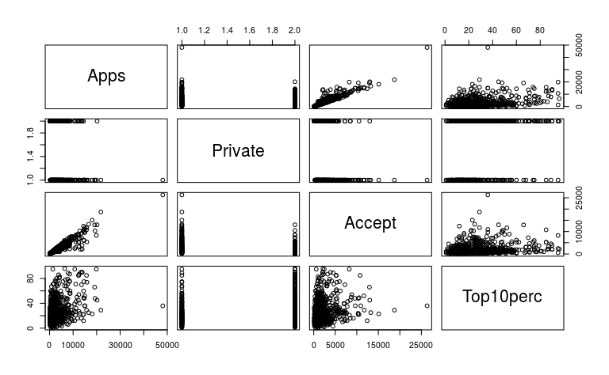

```r
pairs(College[, c(2,1,3,5)])
```

```r
#pairs(Apps ~ Private + Accept + Enroll + Top10perc, data~college)
```

We can also look at this using the `ggpairs` function. Install the library `GGally` if it is not available (and any dependent libraries) and load it.

```r
library(GGally)
ggpairs(College, columns= c(1,3:5, 2))
```

[output not shown]

[output not shown]

*Energetic Students: how do I suppress the message output so that it does not appear in my document ? Post on Piazza if you know or make a pull request!*

What other features do these plots indicate? *(Think about assumptions for linear regression)*

### New variables

Let’s create a new variable `Elite` by binning the `Top10perc` variable. We are going to divide universities into two groups based on whether or not the proportion of students coming from the top 10% of their high school classes exceeds 50 %. We will use the library `dplyr` to illustrate some of the possible transformations and the idea of pipes, which are quite powerful once you get the hang of them!

```r
library(dplyr)
College = College %>%
  mutate(Elite = factor(Top10perc > 50)) %>%
  mutate(Elite =
           recode(Elite, 'TRUE' = "Yes", 'FALSE'="No"))
```

*What is the above doing?* Document the code here.

Compare to the base `R` code:

```r
#evaluate = FALSE can avoid outputing the evaluate result
Elite=rep("No",nrow(College))
Elite[College$Top10perc >50]="Yes"
Elite=as.factor(Elite)
college=data.frame(College ,Elite)
```

*How many Elite universities are there?*

## Next Steps

Update this document and explore the other variables thinking about the objective of predicting `Apps`. Provide a brief summary of what you discover thinking about models to predict `Apps`.